# Parametric bootstrap in a varying coefficient regression model estimated by local adaptive grouped regularization

Wesley Brooks

# Methods

Estimation procedure:

- Estimate a VCR model
- Estimate the bias in coefficient estimation
- Draw from the sampling distribution of the coefficients, correcting for bias
- Use the resampled coefficients to generate resampled response observations
- From the resampled response, estimate the coefficients
- Collect these estimates.

## Estimate a VCR model

The estimated value of the coefficient surface converges thus: $\{n h^d f(s) \}^{1/2} \left(\hat{\beta}(s) - \beta(s) - (2 \kappa_0)^{-1} \kappa_2 h^d \nabla^2 \beta(s) \right) \xrightarrow{D} N\left( 0, \kappa_0^{-2} \nu_0 \Gamma(s)^{-1} \right)$

## Bias in coefficient estimation

The asymptotic distribution of the LAGR-estimated VCR coefficients indicates bias. The asymptotic bias is $(2 \kappa_0)^{-1} \kappa_2 h^d \nabla^2 \beta(s).\label{bias}$ The bias is proportional to the second derivative of the coefficient surface. Therefore, we need to estimate $\nabla^2 \beta(s)$ in order to estimate the bias.

If the bias in estimating $\boldsymbol{\beta}(s)$ is ignored, then the biased estimate will be used for generating the parametric bootstrap draws $\boldsymbol{Y}^*_1, \dots, \boldsymbol{Y}^*_B$. Then the estimation step to reach the bootstrap estimates $\boldsymbol{\beta}^*_1(s), \dots, \boldsymbol{\beta}^*_B(s)$ will introduce another round of bias. Thus, in order use the parametric bootstrap to estimate the distribution of our estimates $\hat{\boldsymbol{\beta}}(s)$, the bias in the original estimate must be corrected.

### Bias correction

In order to estimate the bias, we must estimate the second derivative of the coefficient functions. This is done via kernel smoothing. Letting $\gamma_{1j}(s) = \nabla \hat{\beta}_j(s)$ and $\gamma_2(s) = \nabla^2 \hat{\beta}_j(s)$, the smoothed estimate of the first derivative of coefficient $j$ is $\nabla \hat{\beta_j}(s) = \alpha_0 \gamma_{1j}(s) + \alpha_1 \nabla^2 \gamma_{2j}(s) + \varepsilon.$

Since we have smoothed the first derivative via a locally linear fit, the estimated second derivative is the slope of the first derivative, or $\hat{\alpha}_2(s)$. This estimate is used for estimating the bias of $\hat{\beta}_j(s)$.

This method of estimating the bias of $\hat{\beta}_j(s)$ ignores covariance does not explicitly model the covariance between the second derivatives of different coefficient functions, e.g., $\nabla^2 \hat{\beta}_1(s), \dots, \nabla^2 \hat{\beta}_p(s)$. Whether this is a problem is yet to be determined.

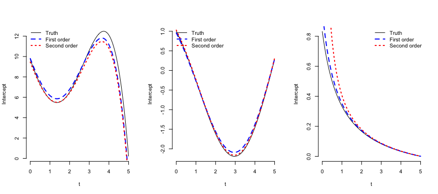

Left to right: the intercept, $\beta_1(s)$, and $\beta_2(s)$ functions used to generate data for the simulation. In each plot, the true coefficient function is the solid black line, the dashed blue line is the coefficient plus the first-order asymptotic estimation bias, and the dotted red line is the coefficient plus the first- and second-order asymptotic estimation bias. The first-order estimation bias is incurred in estimating the coefficient functions from the data. The second-order estimation bias is incurred when estimating a bootstrap draw of the coefficient surface from a first-order estimate without bias correction.

## Parametric bootstrap

Statistics are functions of the data. The distribution of a statistic is a function of the distribution of the data, and the bootstrap is a method of estimation for the data distribution. That is, we assume that $Y \sim G$ and that $F_{\boldsymbol{\theta}_0}$ is a good approximation to $G$, where $\boldsymbol{\theta}_0$ is a parameter vector and our interest is inference on $\boldsymbol{\theta}$. Then the MLE is a function of the observed data $\hat{\boldsymbol{\theta}} = T(Y)$.

The distribution of $\hat{\boldsymbol{\theta}}$ is a function of the distribution $G$, as approximated by $F_{\hat{\boldsymbol{\theta}}}$. The parametric bootstrap is used to simulate $F_{\hat{\boldsymbol{\theta}}}$, then estimation proceeds from the simulated data.

## Simulating from the estimated distribution

Note that $Y_1 \sim N(X_1^T \boldsymbol{\beta}_1, \sigma^2)$ so $(X_1^T W_1 X_1)^{-1} X_1^T W_1 (Y_1 - X_1^T \boldsymbol{\beta}_1) \sim N \left(0, \sigma^2 (X_1^T W_1 X_1)^{-1} X_1^T W_1 W_1 X_1 (X_1^T W_1 X_1)^{-1} \right).$

From this distribution we get the MLE $\hat{\boldsymbol{\beta}}(s)$ and we can draw from the joint distribution of $\boldsymbol{\beta}(s)$.

To estimate the necessary bias correction, the second derivative of $\beta(s)$ is estimated. Since the second derivative is the slope of the slope of $\beta(s)$, we make use of the existing coefficient estimates. Leting $\nabla \hat{\beta}(s)$ be the estimated slopes of the coefficient functions (part of the MLE), we find $\nabla^2 \hat{\beta}(s)$ via a locally linear smooth of $\nabla \hat{\beta}(s)$.

Note: $\beta^{*} \sim N \left(0, \sigma^2 (X_1^T W_1 X_1)^{-1} X_1^T W_1 W_1 X_1 (X_1^T W_1 X_1)^{-1} \right).$

Want: $\tilde{\beta} \xrightarrow{P} truth.$

# Execute

## Bandwidth estimation

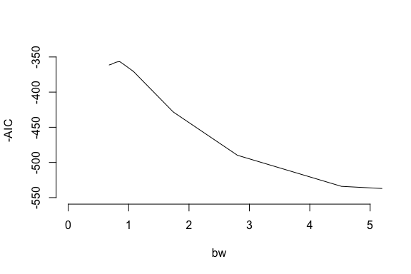

The region of greatest density includes the ten bandwidths with the smallest AIC’s from the profiling step. These ten are:

| bw | loss |
| --- | --- |
| 0.85 | 356.66 |
| 0.85 | 356.71 |
| 0.85 | 356.75 |
| 0.82 | 356.94 |
| 0.78 | 357.68 |
| 0.90 | 359.20 |
| 0.71 | 360.64 |
| 0.67 | 361.40 |
| 1.08 | 370.63 |
| 1.74 | 428.18 |

Histogram of bandwidths drawn from the estimated bandwidth distribution:

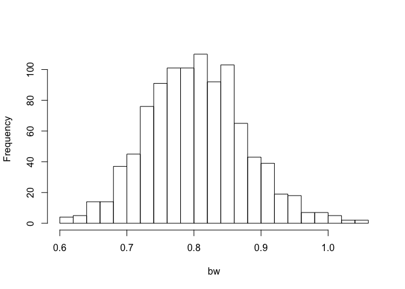

Histogram of draws from the posterior distribution for the bandwidth parameter.

$\mu = \log{ \hat{h} } = -0.22$, $\hat{\sigma}^2 = 0.0084$

## Estimate the best fit

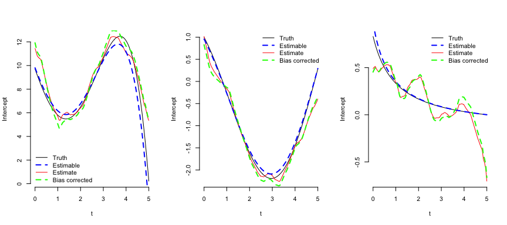

Left to right: the intercept, $\beta_1(s)$, and $\beta_2(s)$ functions, the realizable (biased) versions of the same, their estimates, and the bias-corrected estimates.